# 반도체 기술 심층분석 — HPA/ALD 박막증착과 고압 어닐링

Alpha Hunter Tech Deep Dive #1 | 관련 종목: HPSP (403870)

Author

Alpha Hunter × Chimera AI

Published

May 6, 2026

# 개요: 왜 HPA/ALD인가

**핵심 메시지**

**고압수소어닐링(HPA)**과 **원자층증착(ALD)**은 선단 반도체 공정(3nm→2nm→A14)의 “게이트키퍼” 기술이다. 트랜지스터 구조가 FinFET에서 GAA(Gate-All-Around)로 전환되면서, 나노 수준의 계면 결함 제거(HPA)와 원자 단위 박막 제어(ALD)가 수율과 소자 성능을 좌우한다.

반도체 소자가 미세화될수록 계면(interface) 결함 하나가 소자 전체의 성능을 좌우한다. **HPA(High Pressure Annealing, 고압수소어닐링)**는 25기압, 250~450°C 환경에서 수소를 소자 내부로 확산시켜 Si-SiO₂ 계면의 댕글링 본드(dangling bond)를 패시베이션(passivation)하는 기술이다. **ALD(Atomic Layer Deposition, 원자층증착)**는 전구체(precursor)를 교대로 투입하여 한 원자층씩 박막을 성장시키는 방법으로, 100:1 이상 종횡비 구조에서도 99% 이상의 균일도를 달성한다.

이 두 기술이 2nm GAA, HBM4, CFET 시대에 왜 필수적인지, 그리고 어떤 기업이 수혜를 받는지 분석한다.

# 1 HPA 기술 원리와 진화

## 1.1 고압수소어닐링이란

HPA는 **고순도 수소(H₂) 또는 중수소(D₂)**를 고압(10~25 atm)으로 반도체 웨이퍼에 노출시키는 후처리(post-deposition) 공정이다. 핵심 메커니즘은 다음과 같다:

1. **고압 환경에서 수소 확산 촉진**: 25atm에서 수소 분자의 용해도는 1atm 대비 약 25배 증가, 실리콘 산화막 내부까지 깊이 침투
2. **저온 어닐링 가능**: 기존 어닐링은 600~1000°C가 필요했으나, 고압 환경에서는 250~450°C에서도 동등한 결함 제거 효과 달성
3. **댕글링 본드 패시베이션**: Si-SiO₂ 계면의 미결합 전자(댕글링 본드)를 수소가 결합하여 전하 트랩 밀도(Dit) 감소
4. **구동 전류 최대 15% 향상**: 트랩 밀도 감소로 캐리어 이동도 개선

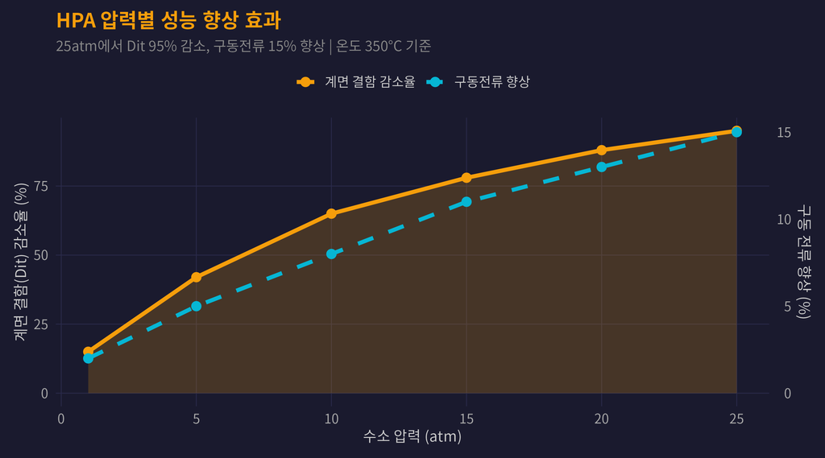

## 1.2 HPA 기술 세대별 진화

HPA 기술은 2015년 imec과의 공동연구에서 시작하여, 4세대에 걸쳐 진화해왔다.

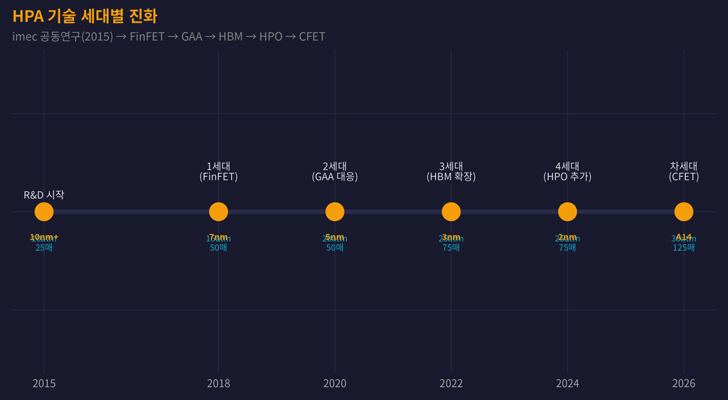

Figure 2: HPA 기술 세대별 진화 타임라인

Table 1: HPA 기술 세대별 비교

[output not shown]

**핵심 인사이트: GAA 전환이 HPA 수요를 구조적으로 확대**

FinFET에서 GAA(나노시트)로 전환되면 채널 표면적이 약 2~3배 증가하여, 패시베이션이 필요한 계면도 비례 증가한다. 이는 HPA 장비 수요의 **구조적 확대**를 의미한다.

# 2 ALD 원자층증착 기술

## 2.1 ALD vs CVD vs PVD 비교

반도체 박막증착은 크게 세 가지 방법으로 나뉜다:

- **PVD(Physical Vapor Deposition)**: 스퍼터링 방식, 빠르지만 단차 피복성 낮음
- **CVD(Chemical Vapor Deposition)**: 화학반응 기반, 중간 수준 균일성
- **ALD(Atomic Layer Deposition)**: 자기제한 반응(self-limiting), 최고 수준 균일성

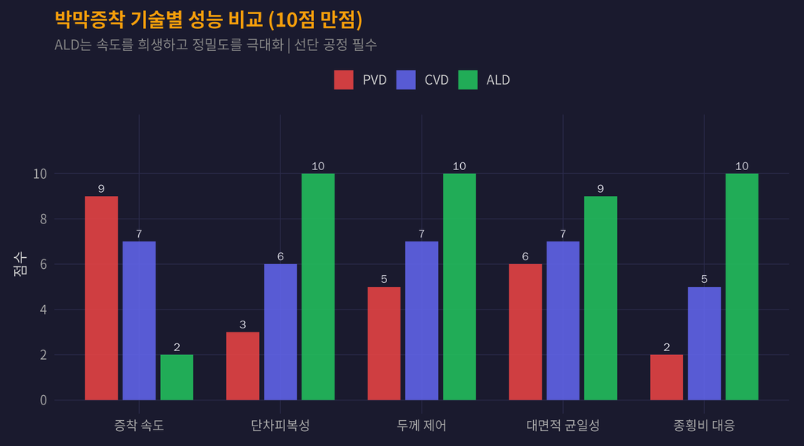

Figure 3: 박막증착 기술별 핵심 성능 비교: PVD vs CVD vs ALD

Table 2: PVD / CVD / ALD 기술 상세 비교

[output not shown]

## 2.2 ALD가 선단 공정에 필수인 이유

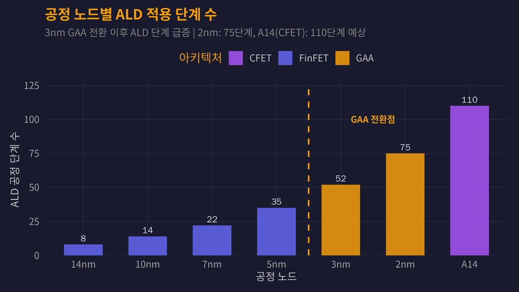

Figure 4: 공정 노드별 ALD 적용 공정 단계 수 증가 추이

**ALD 단계 증가의 의미**

ALD 공정 단계 수가 FinFET 14nm의 8단계에서 GAA 2nm의 75단계로 **약 9배 증가**했다. 이는 ALD 장비 수요가 노드 전환만으로도 구조적으로 성장함을 의미한다.

# 3 선단 공정 로드맵과 HPA/ALD

## 3.1 FinFET → GAA → CFET 전환

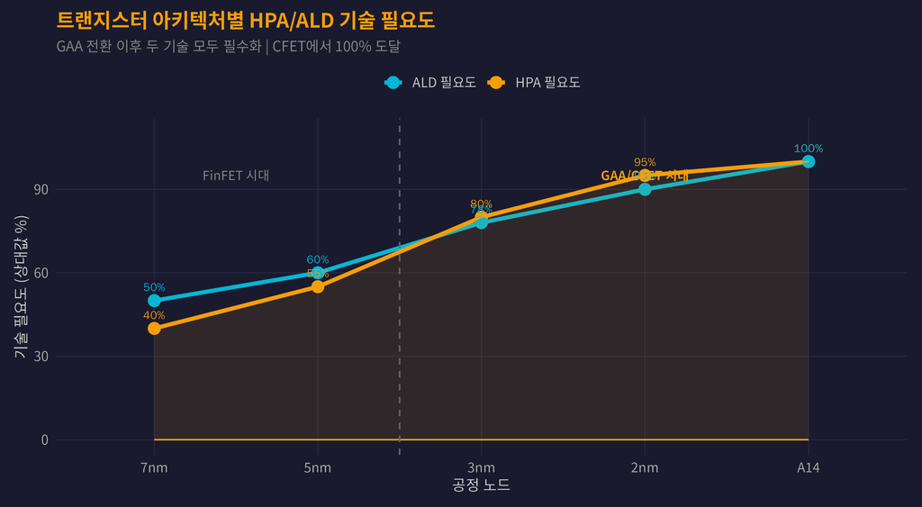

Figure 5: 트랜지스터 아키텍처 진화와 HPA/ALD 필요도

## 3.2 삼성 vs TSMC 선단 공정 경쟁

Table 3: 삼성 vs TSMC 선단 공정 로드맵 비교 (2026년 기준)

[output not shown]

**투자 시사점: 삼성과 TSMC 동시 수혜**

HPSP는 삼성(기존 고객)과 TSMC(신규 진입) 모두에 HPA 장비를 공급한다. 2025~2026년 양사 모두 2nm GAA 양산을 시작하면서, **듀얼 고객 기반**의 동시 수요 증가가 예상된다.

# 4 HPA 시장 경쟁 구도

## 4.1 HPSP vs 예스티(YesTech) 경쟁

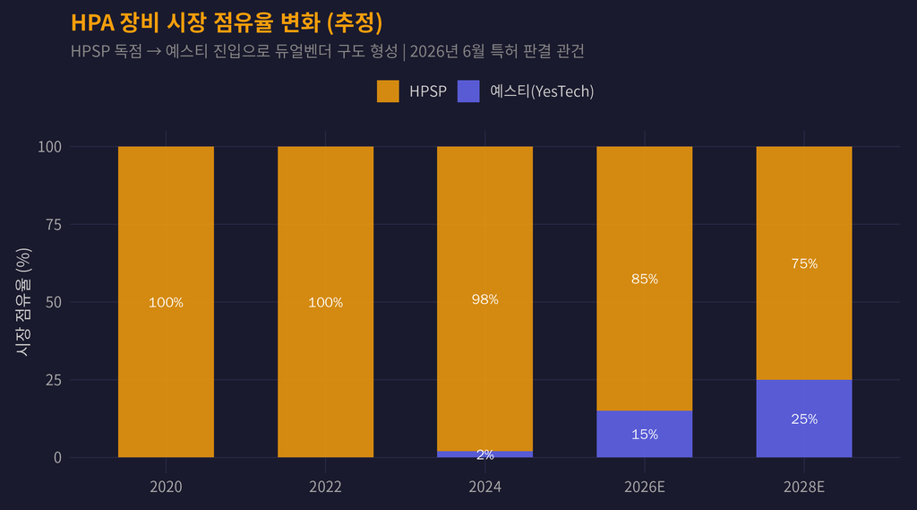

Figure 6: HPA 장비 시장 경쟁 구도 변화

Table 4: HPSP vs 예스티(YesTech) 기술 비교

[output not shown]

**핵심 리스크: 2026년 6월 특허 판결**

HPSP와 예스티 간 핵심 특허 분쟁이 2026년 6월 특허법원에서 판결 예정이다. 결과에 따라 HPA 시장 구도가 크게 달라질 수 있다. 다만, 삼성증권은 “예스티가 진입해도 HPSP 타격은 제한적”이라는 분석을 내놓았다.

# 5 박막증착 장비 시장 분석

## 5.1 글로벌 시장 규모와 성장

[figure not shown]

Figure 7: 글로벌 박막증착 장비 시장 규모 전망 (2020~2032)

## 5.2 주요 경쟁사 시장 점유율

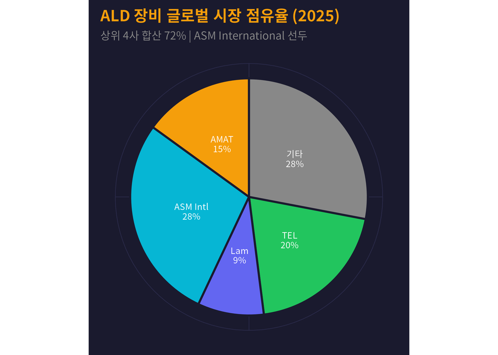

Figure 8: ALD 장비 시장 점유율 (2025년 기준)

# 6 HPO: HPA의 차세대 확장

## 6.1 고압산화(HPO) 기술

**HPO(High Pressure Oxidation)**는 HPA의 기술 플랫폼을 산화 공정으로 확장한 것이다. 고압 환경에서 산화를 수행하면 저온에서도 양질의 산화막을 형성할 수 있어, 열에 민감한 차세대 소자(CFET, 3D NAND 300단+)에 적합하다.

Table 5: HPA vs HPO 기술 비교

[output not shown]

# 7 기술 구조도

## 7.1 HPA 공정 흐름

HPA 장비의 핵심 구조는 다음과 같다:

1. **웨이퍼 로딩**: 카세트에 75~125매 웨이퍼를 수직 적재
2. **챔버 밀봉**: 초고압(25atm) 견딜 수 있는 특수 합금 챔버
3. **가스 주입**: 100% 고순도 수소(H₂) 또는 중수소(D₂) 주입
4. **가압 + 가열**: 25atm, 350°C로 유지 (수 분~수십 분)
5. **수소 확산**: 고압이 SiO₂ 막 내부까지 수소 침투 촉진
6. **결함 패시베이션**: 댕글링 본드(Si-) + H → Si-H 결합 형성
7. **감압 + 언로딩**: 서서히 감압 후 웨이퍼 회수

## 7.2 ALD 증착 사이클

ALD의 자기제한(self-limiting) 반응 사이클은 4단계로 구성된다:

1. **전구체 A 투입**: 금속 전구체(예: TMA, TDMA-Hf) → 표면 흡착
2. **퍼지(Purge)**: 미반응 전구체와 부산물 제거
3. **전구체 B 투입**: 산화제(H₂O, O₃) → 표면 반응으로 단일 원자층 형성
4. **퍼지**: 잔류 가스 제거 → 1 사이클 완료 (약 0.1nm 증착)

이 사이클을 수백~수천 회 반복하여 원하는 두께의 박막을 형성한다.

# 8 투자 시사점

## 8.1 수혜 기업 분석

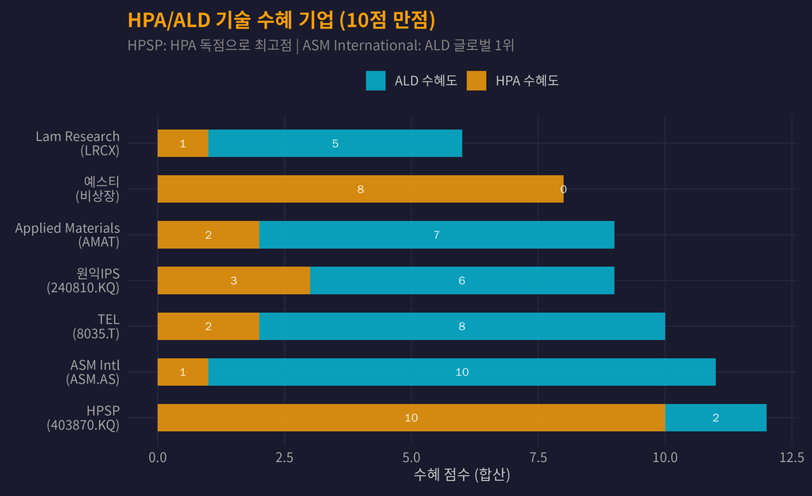

Figure 9: HPA/ALD 기술 확산에 따른 수혜 기업 점수

## 8.2 HPSP 투자 핵심 요약

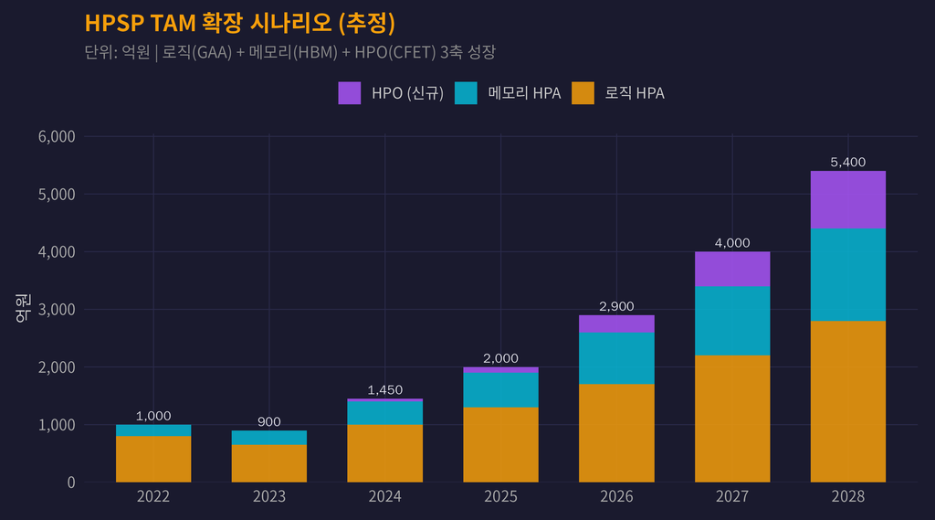

Figure 10: HPSP의 TAM(총 가용 시장) 확장 시나리오

**Alpha Hunter 관점의 투자 시사점**

**단기 (6개월)**

- 2026년 6월 특허 판결이 최대 변수. HPSP 승소 시 독점 재확인, 주가 재평가
- 삼성·TSMC 2nm 양산 본격화에 따른 장비 발주 증가 기대

**장기 (3~5년)**

- CFET 시대 도래 시 HPA+HPO 동시 적용 → 장비 수요 폭발적 성장
- ALD 시장도 CAGR 13%+ 성장, 관련 장비사(ASM, TEL) 동반 수혜

# 9 리스크 요인

1. **예스티 특허 판결**: 2026년 6월 판결에서 HPSP 핵심 특허가 무효화될 경우 경쟁 심화
2. **삼성 의존도**: HPSP 매출의 약 70%가 삼성전자 의존 → 고객 다변화 과제
3. **반도체 사이클**: 업황 하강 시 설비투자 감소 → 장비 발주 지연
4. **기술 대체 리스크**: 새로운 어닐링 기술(플라즈마 어닐링, 레이저 어닐링) 등장 가능성
5. **ALD 쓰루풋 한계**: ALD의 느린 증착 속도를 극복하는 대안 기술 등장 가능

*이 프로젝트는 가상 투자 시뮬레이션 목적으로 작성되었습니다. 실제 투자 권유가 아닙니다.*

*Alpha Hunter × Chimera AI | Tech Deep Dive Series*